# Mitridate, Re di Ponto

Opera seria in drei Akten (1770)

Musik von

Wolfgang Amadeus Mozart

Text von

Vittorio Amedeo Cigna-Santi nach Jean Racine

14 Jahre war Wolfgang Amadeus Mozart erst alt, als er den Auftrag erhielt, für das Mailänder Teatro Regio Ducale eine große, abendfüllende Opera seria zu komponieren, »Mitridate, Re di Ponto«. Viele bedeutende Komponisten hatten zuvor Werke für diese europaweit angesehene Bühne geschaffen. Mozart reihte sich hier mit einer bemerkenswerten Oper ein, basierend auf einem Drama des französischen Tragödiendichters Jean Racine.

Die Geschichte um einen im Niedergang begriffenen König und Kriegsherr, dessen zwei so unterschiedliche Söhne dieselbe Frau lieben, die aber zugleich  
seine eigene Braut ist, inspirierte Mozart zu einer Musik, die gehobenes Pathos und starke Leidenschaften ebenso kennt wie tiefempfundene Emotionen. Er schöpfte aus der Tradition und zeigte sich doch bereits auf einer Höhe, die Kommendes mehr als nur ahnen ließ. Die Uraufführung Ende 1770 wurde zum Triumph für den jugendlichen Komponisten. Ein japanisches Inszenierungsteam um den Regisseur Satoshi Miyagi taucht Mozarts »Mitridate« in ein zauberhaftes Ambiente und lässt verschiedene Welten aufeinandertreffen.

## Termine

So. 11. Dezember 2022 18.00 Uhr

Familienvorstellung BAROCKTAGE 2022 Zum letzten Mal in dieser Spielzeit

[Staatsoper Unter den Linden](https://www.staatsoper-berlin.de/de/ihr-besuch/anfahrt/staatsoper-unter-den-linden.35/)

Dauer: ca. 3:10 h inklusive einer Pause nach dem 2. Akt

Sprache: In italienischer Sprache mit deutschen und englischen Übertiteln

Vorwort 45 Minuten vor Vorstellungsbeginn im Apollosaal  
Die Vorstellungen MITRIDATE, RE DI PONTO am 9.12. und am 11.12.2022 werden von UNITEL in Koproduktion mit NHK aufgezeichnet. Die Produktion wird von medici.tv am 11.12. live gestreamt und von Mezzo TV im März 2023 gesendet.

## Besetzung

- Musikalische Leitung
  - [Marc Minkowski](https://www.staatsoper-berlin.de/de/kuenstler/marc-minkowski.1752/)
- Inszenierung
  - [Satoshi Miyagi](https://www.staatsoper-berlin.de/de/kuenstler/satoshi-miyagi.2650/)
- Bühnenbild
  - [Junpei Kiz](https://www.staatsoper-berlin.de/de/kuenstler/junpei-kiz.2653/)
- Wanddesign
  - [Eri Fukazawa](https://www.staatsoper-berlin.de/de/kuenstler/eri-fukazawa.2654/)
- Kostüme
  - [Kayo Takahashi Deschene](https://www.staatsoper-berlin.de/de/kuenstler/kayo-takahashi-deschene.2655/)
- Licht
  - [Irene Selka](https://www.staatsoper-berlin.de/de/kuenstler/irene-selka.1308/)
- Choreographie
  - [Yu Otagaki](https://www.staatsoper-berlin.de/de/kuenstler/yu-otagaki.2656/)
- Dramaturgie
  - [Detlef Giese](https://www.staatsoper-berlin.de/de/kuenstler/detlef-giese.1014/)
- Mitridate, König von Pontus
  - [Pene Pati](https://www.staatsoper-berlin.de/de/kuenstler/pene-pati.2657/)
- Aspasia
  - [Ana Maria Labin](https://www.staatsoper-berlin.de/de/kuenstler/ana-maria-labin.3117/)
- Sifare
  - [Angela Brower](https://www.staatsoper-berlin.de/de/kuenstler/angela-brower.3025/)
- Farnace
  - [Paul-Antoine Bénos-Djian](https://www.staatsoper-berlin.de/de/kuenstler/paul-antoine-benos-djian.3026/)
- Ismene
  - [Sarah Aristidou](https://www.staatsoper-berlin.de/de/kuenstler/sarah-aristidou.1503/)
- Marzio
  - [Sahy Ratia](https://www.staatsoper-berlin.de/de/kuenstler/sahy-ratia.3206/)
- Arbate
  - [Adriana Bignagni Lesca](https://www.staatsoper-berlin.de/de/kuenstler/adriana-bignagni-lesca.2660/)
- Schauspieler
  - Ken Sugiyama
- - [LES MUSICIENS DU LOUVRE](https://www.staatsoper-berlin.de/de/kuenstler/les-musiciens-du-louvre.1833/)

## Medien

[figure not shown]

- »Mitridate, Re di Ponto« Podcast

[figure not shown]

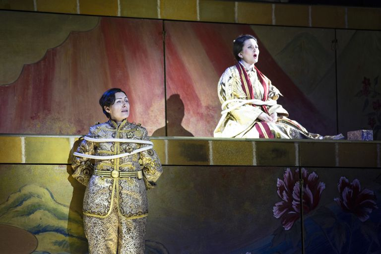

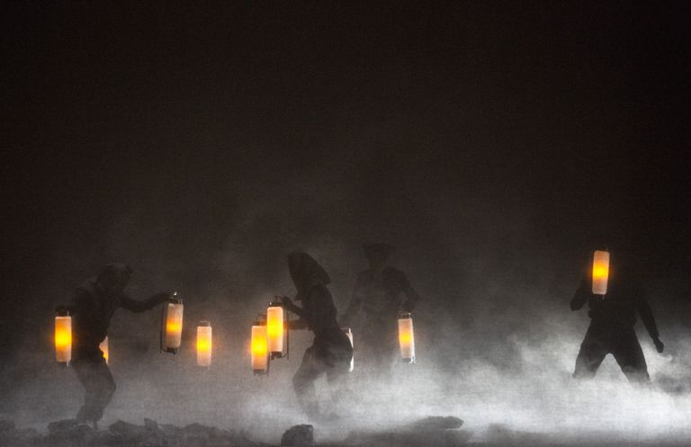

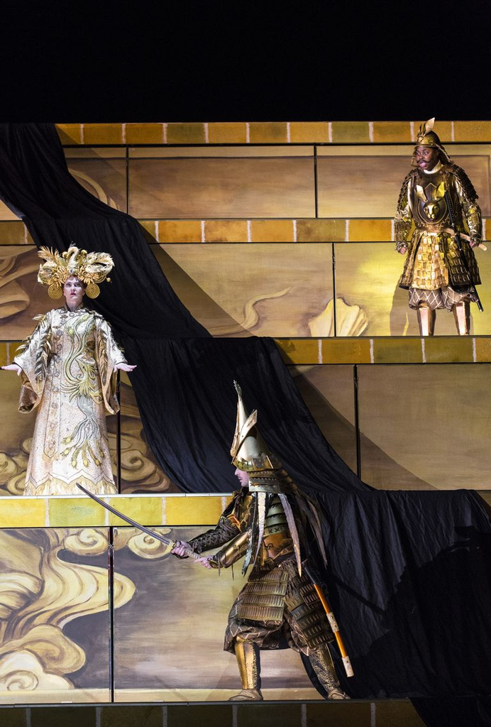

[figure not shown]